# Different Models

Gustavo Hideo Higa Corea

## Quadratic Model

The quadratic model adds a **quadratic term**, that is $\beta_2 X_i^2$, to the simple model. Like this:

$$Y_i = \beta_0 + \beta_1 X_i + \beta_2 X_i^2 + \epsilon_i$$

See below how, in this case, the quadratic model can get closer to the true model compared to a simple model, using simulated and real world data. Also, check how the $R^2$ changes.

### Simulated data

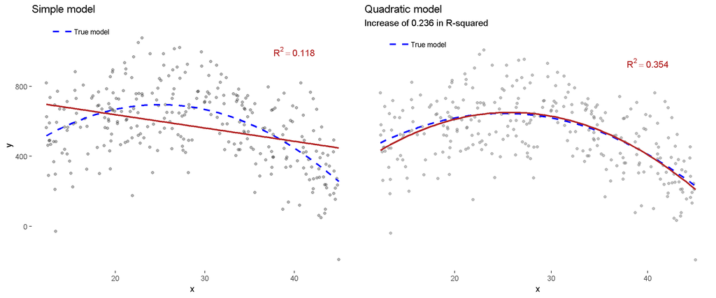

```r
fabData <- data.frame(y=Y_i, x=X_i)


fab.lm.s <- lm(y ~ x, data = fabData)
b.s <- fab.lm.s$coefficients
r2.s <- round(summary(fab.lm.s)$r.squared, 3)


fab.lm <- lm(y ~ x + I(x^2), data=fabData) #Fit an estimated regression model to the fabData.
#pander::pander(summary(fab.lm)) #Summarize your model.
r2 <- round(summary(fab.lm)$r.squared, 3)
b <- fab.lm$coefficients


r2.increase <- round(r2 - r2.s, 3)



# Simple regression
p1 <- fabData %>%
  ggplot(aes(x, y, linetype = "")) +
  geom_point(aes(), alpha = .3) +

  stat_function(fun = function(x) beta0 + beta1*x + beta2*x^2, col = "blue", size = 1) +   #true line
  stat_function(fun = function(x) b.s[1] + b.s[2]*x, col = "firebrick", size = 1, linetype = 1) +    # estimated line

  annotate("text", label = paste("R^2 == ", r2.s), x = 40, parse = T, y = 1000, color = "firebrick") +
  labs(title = "Simple model") +
  scale_linetype_manual(name = "",
                        values = 2,
                        labels = "True model") +
  myTheme





p2 <- fabData %>%
  ggplot(aes(x, y, linetype = "")) +
  geom_point(color = "grey50", alpha = .5) +

  stat_function(fun = function(x) beta0 + beta1*x + beta2*x^2, col = "blue", size = 1) +   #true line
  stat_function(fun = function(x) b[1] + b[2]*x + b[3]*x^2, col = "firebrick", size = 1, linetype = 1) +    # estimated line

  annotate("text", label = paste("R^2 == ", r2), x = 40, parse = T, y = 1000, color = "firebrick") +
  labs(title = "Quadratic model",
       subtitle = paste("Increase of", r2.increase, "in R-squared")) +
  scale_linetype_manual(name = "",
                        values = 2,
                        labels = "True model") +
  myTheme +
  theme(axis.title.y = element_blank(),
        axis.text.y = element_blank(),
        axis.ticks.y = element_blank())

gridExtra::grid.arrange(p1, p2, nrow = 1)
```

#### Summary Simple Model

```r
pander::pander(summary(fab.lm.s))
```

|  | Estimate | Std. Error | t value | Pr(>\|t\|) |
| --- | --- | --- | --- | --- |
| **(Intercept)** | 790 | 36.52 | 21.64 | 4.7e-63 |
| **x** | -7.598 | 1.206 | -6.302 | 1.052e-09 |

Fitting linear model: y ~ x

| Observations | Residual Std. Error | $R^2$ | Adjusted $R^2$ |
| --- | --- | --- | --- |
| 300 | 202.4 | 0.1176 | 0.1147 |

#### Summary Quadratic Model

```r
pander::pander(summary(fab.lm))
```

|  | Estimate | Std. Error | t value | Pr(>\|t\|) |
| --- | --- | --- | --- | --- |
| **(Intercept)** | -132.2 | 93.73 | -1.41 | 0.1595 |
| **x** | 64.72 | 7.005 | 9.239 | 4.943e-18 |
| **I(x^2)** | -1.257 | 0.1204 | -10.44 | 6.228e-22 |

Fitting linear model: y ~ x + I(x^2)

| Observations | Residual Std. Error | $R^2$ | Adjusted $R^2$ |
| --- | --- | --- | --- |
| 300 | 173.4 | 0.3544 | 0.3501 |

#### Assumptions for Simple Model

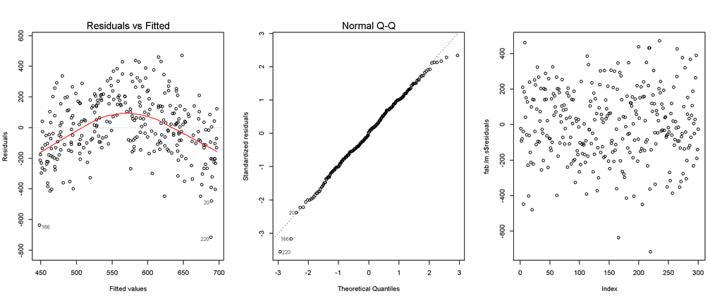

```r
par(mfrow = c(1, 3))
plot(fab.lm.s, which = 1)
plot(fab.lm.s, which = 2)
plot(fab.lm.s$residuals)
```

```r
par(mfrow = c(1, 1))
```

#### Assumptions for Quadratic Model

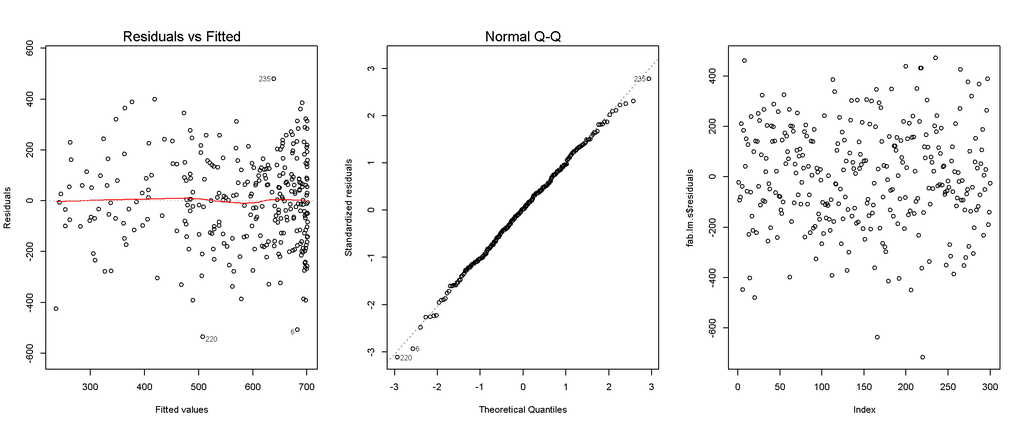

```r
par(mfrow = c(1, 3))
plot(fab.lm, which = 1)
plot(fab.lm, which = 2)
plot(fab.lm.s$residuals)
```

```r
par(mfrow = c(1, 1))
```

The residuals vs fitted plot gets even better than before with a more linear model and more constant in variance of residuals.

### Real data

The dataset used for the regression below is panel from 1963 to 1992 of cigarette consumption in U.S. See how the $R^2$ changes when we use the quadratic model compared to the simple model. Check in the summary how the quadratic model decreases the `Residual Standard Error`, representing the overall distance from the fitted model to the data points.

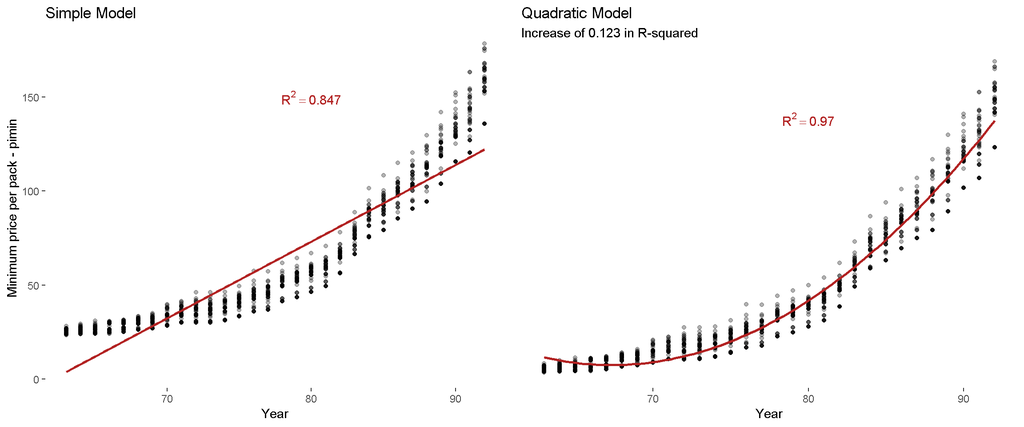

```r
cigar <- Ecdat::Cigar

lm.c.s <- lm(pimin ~ year, data = cigar)
#pander::pander(summary(lm.c.s))
bc.s <- lm.c.s$coefficients
r2.s <- round(summary(lm.c.s)$r.squared, 3)

lm.c <- lm(pimin ~ year + I(year^2), data = cigar)
#pander::pander(summary(lm.c))
bc <- lm.c$coefficients
r2 <- round(summary(lm.c)$r.squared, 3)


r2.increase <- round(r2 - r2.s, 3)

p1 <- cigar %>%
  ggplot(aes(year, pimin)) +
  geom_point(alpha = .3) +
  stat_function(fun = function(x) bc.s[1] + bc.s[2]*x, color = "firebrick", size = 1) +
  annotate("text", label = paste("R^2 == ", r2.s), x = 80, parse = T, y = 150, color = "firebrick") +
  myTheme +
  labs(x = "Year",
       y = "Minimum price per pack - pimin",
       title = "Simple Model")



p2 <- cigar %>%
  ggplot(aes(year, pimin)) +
  geom_point(alpha = .3) +
  stat_function(fun = function(x) bc[1] + bc[2]*x + bc[3]*x^2, color = "firebrick", size = 1) +
  annotate("text", label = paste("R^2 == ", r2), x = 80, parse = T, y = 150, color = "firebrick") +
  myTheme +
  labs(x = "Year",
       title = "Quadratic Model",
       subtitle = paste("Increase of", r2.increase, "in R-squared")) +
  theme(axis.title.y = element_blank(),
        axis.text.y = element_blank(),
        axis.ticks.y = element_blank())


gridExtra::grid.arrange(p1, p2, nrow = 1)
```

#### Summary Simple Model

```r
pander::pander(summary(lm.c.s))
```

|  | Estimate | Std. Error | t value | Pr(>\|t\|) |
| --- | --- | --- | --- | --- |
| **(Intercept)** | -252.8 | 3.638 | -69.49 | 0 |
| **year** | 4.073 | 0.04665 | 87.32 | 0 |

Fitting linear model: pimin ~ year

| Observations | Residual Std. Error | $R^2$ | Adjusted $R^2$ |
| --- | --- | --- | --- |
| 1380 | 15 | 0.8469 | 0.8468 |

#### Summary Quadratic Model

```r
pander::pander(summary(lm.c))
```

|  | Estimate | Std. Error | t value | Pr(>\|t\|) |
| --- | --- | --- | --- | --- |
| **(Intercept)** | 938.9 | 15.93 | 58.96 | 0 |
| **year** | -27.07 | 0.4146 | -65.3 | 0 |
| **I(year^2)** | 0.2009 | 0.002671 | 75.22 | 0 |

Fitting linear model: pimin ~ year + I(year^2)

| Observations | Residual Std. Error | $R^2$ | Adjusted $R^2$ |
| --- | --- | --- | --- |
| 1380 | 6.638 | 0.97 | 0.97 |

#### Assumptions for Simple Model

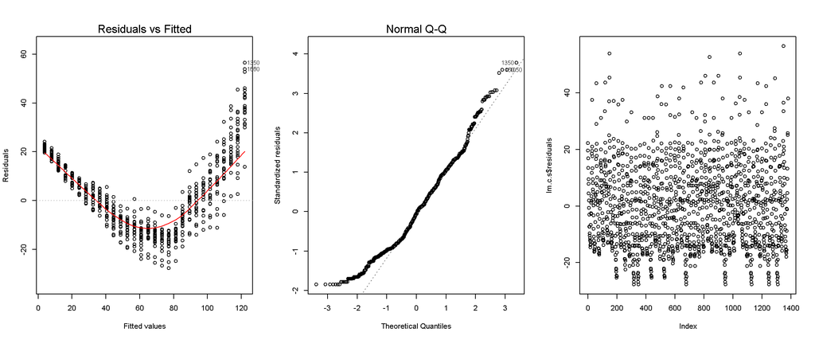

```r
par(mfrow = c(1, 3))
plot(lm.c.s, which = 1)
plot(lm.c.s, which = 2)
plot(lm.c.s$residuals)
```

```r
par(mfrow = c(1, 1))
```

The residuals vs fitted plot shows that the model is not linear and the variance is not constant.

#### Assumptions for Quadratic Model

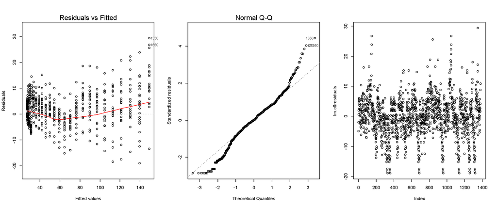

```r
par(mfrow = c(1, 3))
plot(lm.c, which = 1)
plot(lm.c, which = 2)
plot(lm.c$residuals)
```

```r
par(mfrow = c(1, 1))
```

The linearity improves compared to the simple model, but the variance is still not constant.

## Cubic Model

The **Cubic Model** differs from the simple model by using the `x` variable 3 times: $\beta_1X_i$, $\beta_2X_i^2$ and $\beta_3X_i^3$. The $X_i^3$ is called the `cubic term`.  
See below the mathematical model for the cubic model:

$$Y_i = \beta_0 + \beta_1X_i + \beta_2X_i^2 + \beta_3X_i^3 + \epsilon_i$$

Check in the comparisons below, first using a simulated data (to see how close we can get from the **true model**) and later with a real world dataset, how the cubic model helps to improve our model.

### Simulated data

[figure not shown]

```r
fab.lm3.s <- lm(y ~ x, data = fabData)
r2.s <- round(summary(fab.lm3.s)$r.squared, 3)
b3.s <- fab.lm3.s$coefficients


fab.lm3 <- lm(y ~ x + I(x^2) + I(x^3), data = fabData)
#pander::pander(summary(fab.lm3))
r2 <- round(summary(fab.lm3)$r.squared, 3)
b3 <- fab.lm3$coefficients

r2.increase <- round(r2 - r2.s, 3)



p1 <- fabData %>%
  ggplot(aes(x, y, linetype = "")) +
  geom_point(alpha = .3) +

  stat_function(fun = function(x) beta0 + beta1*x + (beta2)*x^2 + (beta3)*x^3,
                col = "blue", size = 1) +   #true line
  stat_function(fun = function(x) b3.s[1] + b3.s[2]*x, col = "firebrick", size = 1, linetype = 1) +

  annotate("text", label = paste("R^2 == ", r2.s), x = 25, parse = T, y = 3500, color = "firebrick") +
  labs(title = "Simple model") +
  scale_linetype_manual(values = 2,
                        labels = "True model") +
  myTheme



p2 <- fabData %>%
  ggplot(aes(x, y, linetype = "")) +
  geom_point(alpha = .3) +

  stat_function(fun = function(x) beta0 + beta1*x + (beta2)*x^2 + (beta3)*x^3,
                col = "blue", size = 1) +   #true line
  stat_function(fun = function(x) b3[1] + b3[2]*x + b3[3]*x^2 + b3[4]*x^3, col = "firebrick", size = 1, linetype = 1) +

  annotate("text", label = paste("R^2 == ", r2.s), x = 25, parse = T, y = 3500, color = "firebrick") +
  labs(title = "Cubic model",
       subtitle = paste("Increase of", r2.increase, "in R-squared")) +
  myTheme +
  theme(axis.title.y = element_blank(),
        axis.text.y = element_blank(),
        axis.ticks.y = element_blank()) +
  scale_linetype_manual(values = 2,
                        labels = "True model")



gridExtra::grid.arrange(p1, p2, nrow = 1)
```

#### Summary Simple Model

```r
pander::pander(summary(fab.lm3.s))
```

|  | Estimate | Std. Error | t value | Pr(>\|t\|) |
| --- | --- | --- | --- | --- |
| **(Intercept)** | -109.5 | 94.07 | -1.164 | 0.2459 |
| **x** | -123.8 | 4.99 | -24.82 | 1.066e-62 |

Fitting linear model: y ~ x

| Observations | Residual Std. Error | $R^2$ | Adjusted $R^2$ |
| --- | --- | --- | --- |
| 200 | 1321 | 0.7568 | 0.7555 |

#### Summary Cubic Model

```r
pander::pander(summary(fab.lm3))
```

|  | Estimate | Std. Error | t value | Pr(>\|t\|) |
| --- | --- | --- | --- | --- |
| **(Intercept)** | 130.2 | 74.75 | 1.742 | 0.08304 |
| **x** | 0.5872 | 6.394 | 0.09183 | 0.9269 |
| **I(x^2)** | 0.08438 | 0.1835 | 0.4599 | 0.6461 |
| **I(x^3)** | -0.1881 | 0.009595 | -19.61 | 4.295e-48 |

Fitting linear model: y ~ x + I(x^2) + I(x^3)

| Observations | Residual Std. Error | $R^2$ | Adjusted $R^2$ |
| --- | --- | --- | --- |
| 200 | 688.3 | 0.9346 | 0.9336 |

#### Assumptions for Simple Model

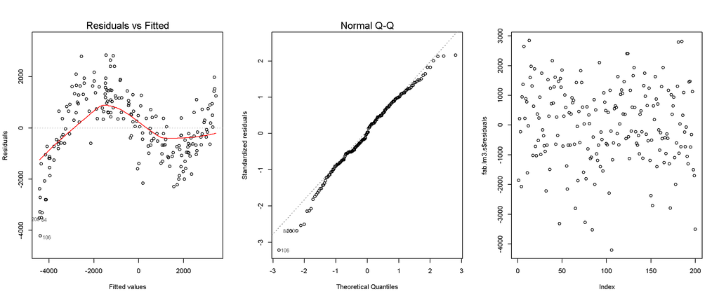

```r
par(mfrow = c(1, 3))
plot(fab.lm3.s, which = 1)
plot(fab.lm3.s, which = 2)
plot(fab.lm3.s$residuals)
```

```r
par(mfrow = c(1, 1))
```

The residuals vs fitted plot shows that the model is not linear and the variance is not constant.

#### Assumptions for Cubic Model

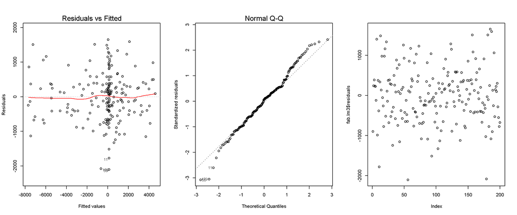

```r
par(mfrow = c(1, 3))
plot(fab.lm3, which = 1)
plot(fab.lm3, which = 2)
plot(fab.lm3$residuals)
```

```r
par(mfrow = c(1, 1))
```

### Real data

The dataset used below contain data for body temperature series of two beavers. We will use the temperature (`temp`) in Celcius degrees and the time of the day (`time`) when the temperature was collected.

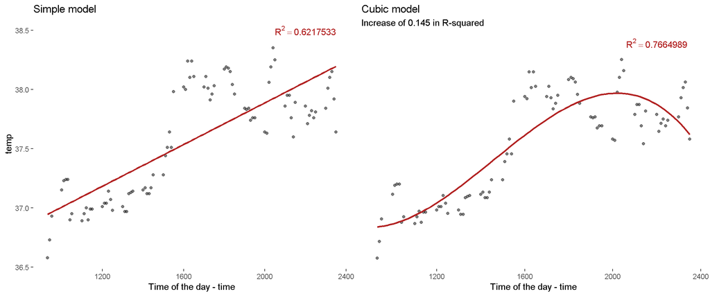

```r
beavers <- beaver2 %>%
  filter(time >= 500)

lm.b.s <- lm(temp ~ time, data = beavers)
#pander::pander(summary(lm.b.s))
r2.s <- summary(lm.b.s)$r.squared
b.s <- lm.b.s$coefficients

lm.b <- lm(temp ~ time + I(time^2) + I(time^3), data = beavers)
#pander::pander(summary(lm.b))
r2 <- summary(lm.b)$r.squared
b <- lm.b$coefficients


r2.increase <- round(r2 - r2.s, 3)


# simple model
p1 <- beavers %>%
  ggplot(aes(time, temp)) +
  geom_point(alpha = .5) +
  stat_function(fun = function(x) b.s[1] + b.s[2]*x, col = "firebrick", size = 1) +
  annotate("text", label = paste("R^2 == ", r2.s), x = 2200, parse = T, y = 38.5, color = "firebrick") +
  myTheme +
  labs(x = "Time of the day - time",
       title = "Simple model")



# cubic model
p2 <- beavers %>%
  ggplot(aes(time, temp)) +
  geom_point(alpha = .5) +
  stat_function(fun = function(x) b[1] + b[2]*x + b[3]*x^2 + b[4]*x^3, col = "firebrick", size = 1) +
  annotate("text", label = paste("R^2 == ", r2), x = 2200, parse = T, y = 38.5, color = "firebrick") +
  myTheme +
  labs(x = "Time of the day - time",
       title = "Cubic model",
       subtitle = paste("Increase of", r2.increase, "in R-squared")) +
  theme(axis.title.y = element_blank(),
        axis.text.y = element_blank(),
        axis.ticks.y = element_blank())


gridExtra::grid.arrange(p1, p2, nrow = 1)
```

#### Summary Simple Model

```r
pander::pander(summary(lm.b.s))
```

|  | Estimate | Std. Error | t value | Pr(>\|t\|) |
| --- | --- | --- | --- | --- |
| **(Intercept)** | 36.13 | 0.1266 | 285.3 | 1.649e-128 |
| **time** | 0.0008795 | 7.441e-05 | 11.82 | 1.235e-19 |

Fitting linear model: temp ~ time

| Observations | Residual Std. Error | $R^2$ | Adjusted $R^2$ |
| --- | --- | --- | --- |
| 87 | 0.2905 | 0.6218 | 0.6173 |

#### Summary Cubic Model

```r
pander::pander(summary(lm.b))
```

|  | Estimate | Std. Error | t value | Pr(>\|t\|) |
| --- | --- | --- | --- | --- |
| **(Intercept)** | 40.31 | 1.75 | 23.04 | 8.214e-38 |
| **time** | -0.009071 | 0.003409 | -2.661 | 0.009357 |
| **I(time^2)** | 7.317e-06 | 2.134e-06 | 3.43 | 0.000944 |
| **I(time^3)** | -1.674e-09 | 4.306e-10 | -3.887 | 0.0002035 |

Fitting linear model: temp ~ time + I(time^2) + I(time^3)

| Observations | Residual Std. Error | $R^2$ | Adjusted $R^2$ |
| --- | --- | --- | --- |
| 87 | 0.231 | 0.7665 | 0.7581 |

#### Assumptions for Simple Model

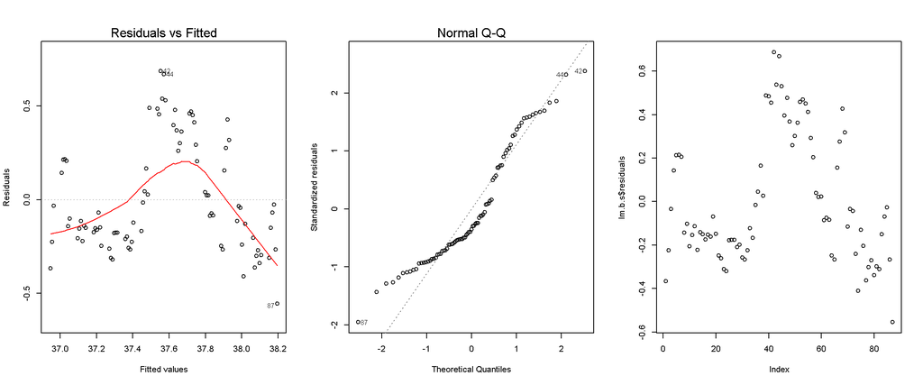

```r
par(mfrow = c(1, 3))
plot(lm.b.s, which = 1)
plot(lm.b.s, which = 2)
plot(lm.b.s$residuals)
```

```r
par(mfrow = c(1, 1))
```

The assumptions are not satisfied. The residuals vs fitted plot shows that the model is not linear and the $Y$ variance is not constant. The qq-plot shows that the data is not normally distributed. The residuals vs order plot shows how the error-term is not independent.

#### Assumptions for Cubic Model

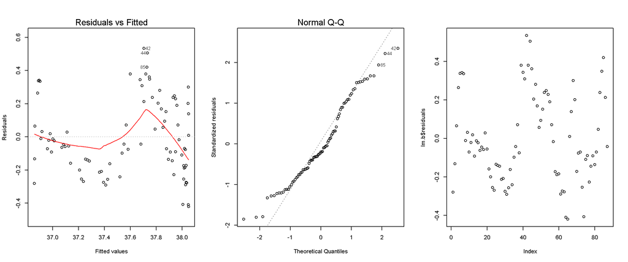

```r
par(mfrow = c(1, 3))
plot(lm.b, which = 1)
plot(lm.b, which = 2)
plot(lm.b$residuals)
```

```r
par(mfrow = c(1, 1))
```

The assumptions don’t change much compared to the simple model.

## Two-Lines Model

The **Two-line model** uses a quantitative $X_{1i}$ variable and a qualitative variable (e.g. “0,1”, “treated, untreated”, “male, female”, etc) $X_{2i}$.  
The mathematical model is writen as follows:

$$Y_i = \beta_0 + \beta_1 X_{1i} + \beta_{2} \underbrace{X_{2i}}_\text{groups 0 and 1} + \beta_{3} \underbrace{X_{1i} X_{2i}}_\text{interactive term} + \epsilon_i$$

Check in the comparisons below, first using a simulated data (to see how close we can get from the **true model**) and later with a real world dataset, how the two-line model helps to improve our model by increasing $R^2$ and decreasing `Residual standard error`.

### Simulated data

The R-squared for the Two-line model represents the average R-squared from both lines

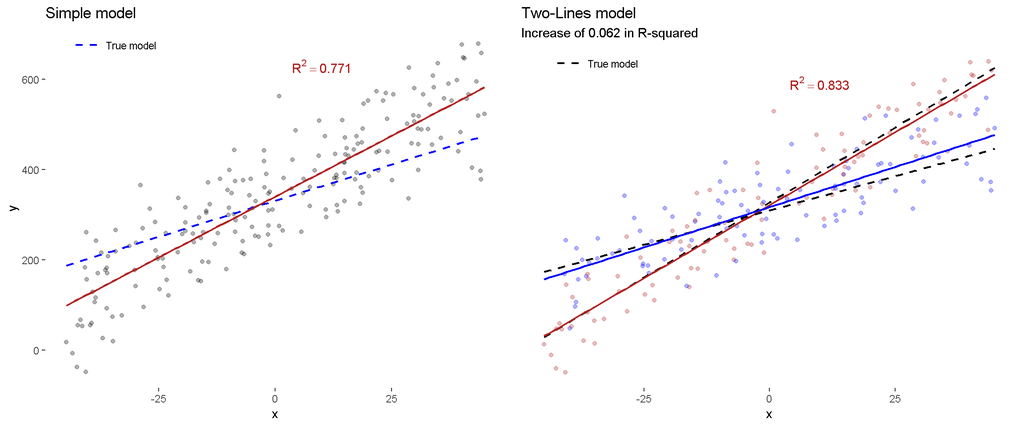

```r
fab.lm.s <- lm(y ~ x, data = fabData)
b.s <- fab.lm.s$coefficients
r2.s <- round(summary(fab.lm.s)$r.squared, 3)



fab.lm <- lm(y ~ x + z + x:z, data = fabData)
b <- fab.lm$coefficients
r2 <- round(summary(fab.lm)$r.squared, 3)



r2.increase <- round(r2 - r2.s, 3)







p1 <- fabData %>%
  ggplot(aes(x, y, linetype = "")) +
  geom_point(alpha = .3) +
  #scale_color_manual(values = c("firebrick", "blue"), guide = F) +

  stat_function(fun = function(x) (beta0+beta2) + (beta1+beta3)*x, col = "blue", size = .8) +
  stat_function(fun = function(x) b.s[1] + b.s[2]*x, col = "firebrick", size = .8, linetype = 1) +

  annotate("text", label = paste("R^2 == ", r2.s), x = 10, parse = T, y = 630, color = "firebrick") +
  labs(title = "Simple model") +
  scale_linetype_manual(values = 2,
                        labels = "True model") +
  myTheme




p2 <- fabData %>%
  ggplot(aes(x, y, color = factor(z), linetype = "")) +
  geom_point(alpha = .3) +
  scale_color_manual(values = c("firebrick", "blue"), guide = F) +
  # Group 0
  stat_function(fun = function(x) beta0 + beta1*x, col = "black", size = .8) +  # true line
  stat_function(fun = function(x) b[1] + b[2]*x, col = "firebrick", size = .8, linetype = 1) +  # estimated line
  # Group 1
  stat_function(fun = function(x) (beta0+beta2) + (beta1+beta3)*x, col = "black", size = .8) +  # true line
  stat_function(fun = function(x) (b[1]+b[3]) + (b[2]+b[4])*x, col = "blue", size = .8, linetype = 1) +  # estimated line

  annotate("text", label = paste("R^2 == ", r2), x = 10, parse = T, y = 630, color = "firebrick") +
  labs(title = "Two-Lines model",
       subtitle = paste("Increase of", r2.increase, "in R-squared")) +
  myTheme +
  theme(axis.title.y = element_blank(),
        axis.text.y = element_blank(),
        axis.ticks.y = element_blank()) +
  scale_linetype_manual(values = 2,
                 labels = "True model")



gridExtra::grid.arrange(p1, p2, nrow = 1)
```

#### Summary Simple Model

```r
pander::pander(summary(fab.lm.s))
```

|  | Estimate | Std. Error | t value | Pr(>\|t\|) |
| --- | --- | --- | --- | --- |
| **(Intercept)** | 340.3 | 5.308 | 64.11 | 2.174e-134 |
| **x** | 5.376 | 0.2081 | 25.83 | 2.489e-65 |

Fitting linear model: y ~ x

| Observations | Residual Std. Error | $R^2$ | Adjusted $R^2$ |
| --- | --- | --- | --- |
| 200 | 75.06 | 0.7712 | 0.77 |

#### Summary Two-lines Model

```r
pander::pander(summary(fab.lm))
```

|  | Estimate | Std. Error | t value | Pr(>\|t\|) |
| --- | --- | --- | --- | --- |
| **(Intercept)** | 343.6 | 6.537 | 52.56 | 1.739e-117 |
| **x** | 6.808 | 0.2447 | 27.82 | 5.616e-70 |
| **z** | -4.524 | 9.111 | -0.4965 | 0.6201 |
| **x:z** | -3.054 | 0.3578 | -8.536 | 3.799e-15 |

Fitting linear model: y ~ x + z + x:z

| Observations | Residual Std. Error | $R^2$ | Adjusted $R^2$ |
| --- | --- | --- | --- |
| 200 | 64.38 | 0.8334 | 0.8309 |

#### Assumptions for Simple Model

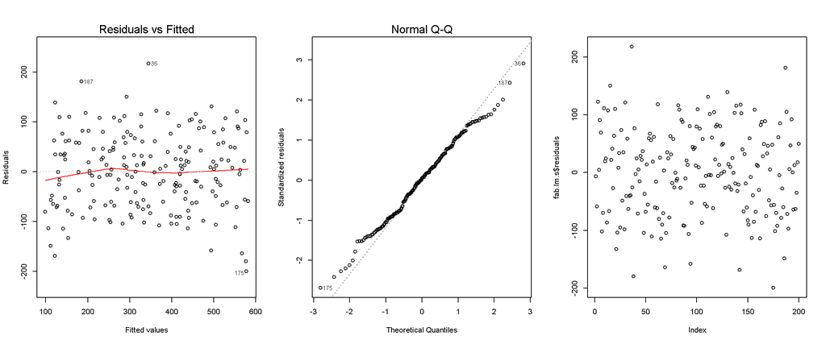

```r
par(mfrow = c(1, 3))
plot(fab.lm.s, which = 1)
plot(fab.lm.s, which = 2)
plot(fab.lm.s$residuals)
```

```r
par(mfrow = c(1, 1))
```

All the assumptions are apparently good. The model is linear, constant variance for Y-values (with a few exceptions of outliers), normally distributed, and error terms are independent.

#### Assumptions for Two-lines Model

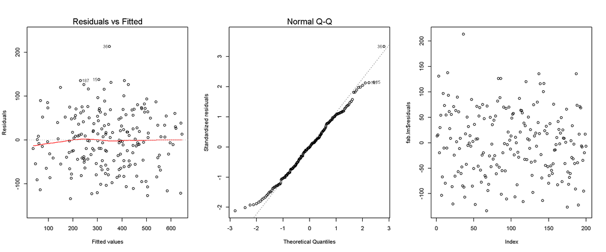

```r
par(mfrow = c(1, 3))
plot(fab.lm, which = 1)
plot(fab.lm, which = 2)
plot(fab.lm$residuals)
```

```r
par(mfrow = c(1, 1))
```

With the exception of a couple of outliers, the model is linear with constant variance. The other plots look good.

### Real data

The dataset used in the model below contains data on enzymatic reaction involving untreated cells or cells treated with Puromycin. We will use the reaction rates (`rate`), the substrate concentration (`conc`) and treatment (`state`)

The R-squared for the Two-line model represents the average R-squared from both lines

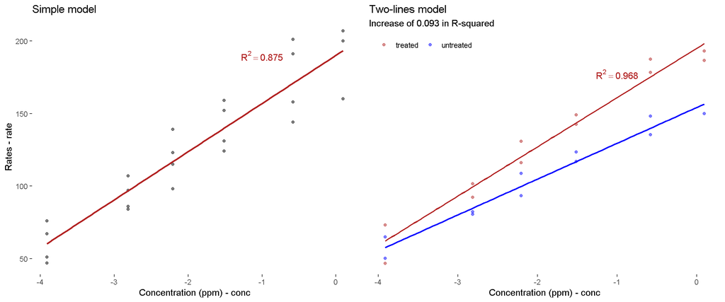

```r
lm.t.s <- lm(rate ~ I(log(conc)), data = Puromycin)
bt.s <- lm.t.s$coefficients
r2.s <- round(summary(lm.t.s)$r.squared, 3)




lm.p <- lm(rate ~ I(log(conc)) + state + I(log(conc)):state, data = Puromycin)
#pander::pander(summary(lm.p))
b <- lm.p$coefficients
r2 <- round(summary(lm.p)$r.squared, 3)



r2.increase <- round(r2 - r2.s, 3)







p1 <- Puromycin %>%
  ggplot(aes(log(conc), rate)) +
  geom_point(alpha = .5) +
  stat_function(fun = function(x) bt.s[1] + bt.s[2]*x, col = "firebrick", size = 1) +
  #scale_color_manual(values = c("firebrick", "blue")) +
  annotate("text", label = paste("R^2 == ", r2.s), x = -1, parse = T, y = 190, color = "firebrick") +
  labs(x = "Concentration (ppm) - conc",
       y = "Rates - rate",
       title = "Simple model") +
  myTheme



p2 <- Puromycin %>%
  ggplot(aes(log(conc), rate, color = state)) +
  geom_point(alpha = .5) +

  # Treated group
  stat_function(fun = function(x) b[1] + b[2]*x, color = "firebrick", size = .8) +
  # Unreated group
  stat_function(fun = function(x) (b[1]+b[3]) + (b[2]+b[4])*x, color = "blue", size = .8) +

  scale_color_manual(values = c("firebrick", "blue")) +
  annotate("text", label = paste("R^2 == ", r2), x = -1, parse = T, y = 190, color = "firebrick") +

  labs(x = "Concentration (ppm) - conc",
       y = "Rates - rate",
       title = "Two-lines model",
       subtitle = paste("Increase of", r2.increase, "in R-squared")) +
  myTheme +
  theme(axis.title.y = element_blank(),
        axis.text.y = element_blank(),
        axis.ticks.y = element_blank())

gridExtra::grid.arrange(p1, p2, nrow = 1)
```

#### Summary Simple Model

```r
pander::pander(summary(lm.t.s))
```

|  | Estimate | Std. Error | t value | Pr(>\|t\|) |
| --- | --- | --- | --- | --- |
| **(Intercept)** | 190.1 | 6.332 | 30.02 | 9.826e-19 |
| **I(log(conc))** | 33.2 | 2.739 | 12.12 | 6.039e-11 |

Fitting linear model: rate ~ I(log(conc))

| Observations | Residual Std. Error | $R^2$ | Adjusted $R^2$ |
| --- | --- | --- | --- |
| 23 | 17.2 | 0.875 | 0.869 |

#### Summary Two-lines Model

```r
pander::pander(summary(lm.p))
```

|  | Estimate | Std. Error | t value | Pr(>\|t\|) |
| --- | --- | --- | --- | --- |
| **(Intercept)** | 209.2 | 4.453 | 46.97 | 4.037e-21 |
| **I(log(conc))** | 37.11 | 1.968 | 18.86 | 9.246e-14 |
| **stateuntreated** | -44.61 | 6.811 | -6.549 | 2.854e-06 |
| **I(log(conc)):stateuntreated** | -10.13 | 2.937 | -3.448 | 0.002692 |

Fitting linear model: rate ~ I(log(conc)) + state + I(log(conc)):state

| Observations | Residual Std. Error | $R^2$ | Adjusted $R^2$ |
| --- | --- | --- | --- |
| 23 | 9.151 | 0.968 | 0.9629 |

#### Assumptions for Simple Model

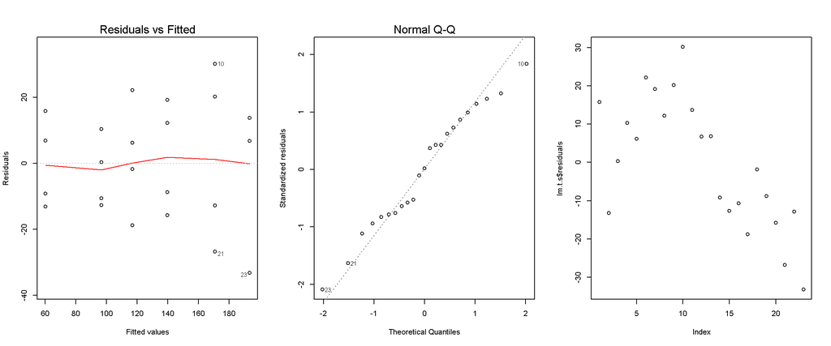

```r
par(mfrow = c(1, 3))
plot(lm.t.s, which = 1)
plot(lm.t.s, which = 2)
plot(lm.t.s$residuals)
```

```r
par(mfrow = c(1, 1))
```

The residuals vs fitted plot and qq-plot look fairly good. The residuals vs order plot clearly shows that the error terms for this model is not independent.

#### Assumptions for Two-lines Model

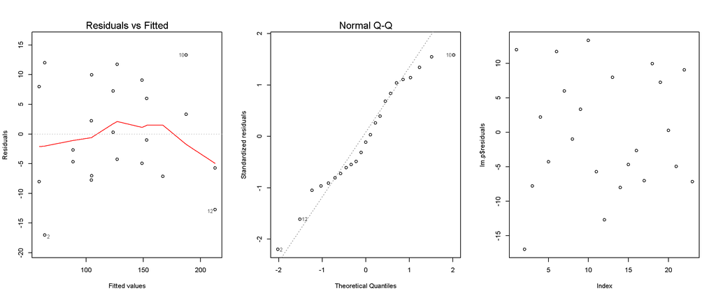

```r
par(mfrow = c(1, 3))
plot(lm.p, which = 1)
plot(lm.p, which = 2)
plot(lm.p$residuals)
```

```r
par(mfrow = c(1, 1))
```

The residuals vs fitted plot shows how the model is linear and the variance is constant, with the exception of a couple of outliers. The qq-plot shows that the distribution is skewed. The error terms can be considered independent.